# Longitudinal FLAIR Radiomics and Survival in the LUMIERE Cohort

Somayeh Sarirchi

2025-12-03

# 1 Background

Glioblastoma patients are followed longitudinally using MRI, including FLAIR imaging. Radiomics features extracted from these images may capture tumor shape and texture properties that provide additional prognostic information.

This report analyzes the public LUMIERE dataset provided at:

Yannick Suter (2022).  
The LUMIERE Dataset: Longitudinal Glioblastoma MRI with Expert RANO Evaluation.  
Figshare. https://doi.org/10.6084/m9.figshare.c.5904905.v1

Since the raw MRI and CSV files are large, they are not included in this repository. Please download the CSV files from the DOI and place them in a `data/` folder next to this Rmd file.

# 2 Data and Preprocessing

The preprocessed time-dependent dataset used in this report is stored as  
`data/LUMIERE_TD_FINAL.csv`. A companion script (`scripts/01_preprocess_to_TD_FINAL.R`)  
demonstrates how this file can be derived from the original LUMIERE CSV files.

## 2.1 Required packages

```r
library(tidyverse)
library(stringr)
library(readr)
library(survival)
library(survminer)
library(caret)
library(pheatmap)
library(corrplot)
library(riskRegression)
library(pec)
```

## 2.2 File paths

These are relative paths suitable for a GitHub repository structure like:

- `data/` : input CSV files downloaded from figshare
- `results/` : output files created by preprocessing and analysis scripts

```r
PATH_DEMO  <- "data/LUMIERE-Demographics_Pathology.csv"
PATH_RANO  <- "data/LUMIERE-ExpertRating-v202211.csv"
PATH_MR    <- "data/LUMIERE-MRinfo.csv"
PATH_PYRAD <- "data/LUMIERE-pyradiomics-deepbratumia-features.csv"

OUT_RAW    <- "results/LUMIERE_Longitudinal_ALL_FLAIR_RAW.csv"
OUT_CLEAN  <- "results/LUMIERE_Longitudinal_CLEAN_ALL_FLAIR.csv"
OUT_FINAL  <- "data/LUMIERE_TD_FINAL.csv"
```

## 2.3 Load survival-ready dataset

This assumes that a separate preprocessing script (for example `LUMIERE_full_survival_analysis.R`) has already created `OUT_FINAL` with start/stop/event, clinical variables and reduced radiomics features.

```r
# Load the final time-dependent dataset for analysis
library(readr)
library(here)

OUT_FINAL <- here("data", "LUMIERE_TD_FINAL.csv")

mydata <- read_csv(OUT_FINAL)

cat("Dimensions of dataset:\n")
```

```
## Dimensions of dataset:
```

```r
print(dim(mydata))
```

```
## [1] 584  46
```

# 3 Radiomics overview (optional)

```r
num_df <- mydata %>% dplyr::select(where(is.numeric))

cm <- cor(num_df, use = "pairwise.complete.obs", method = "spearman")
d  <- as.dist(1 - abs(cm))

pheatmap::pheatmap(
  cm,
  clustering_distance_rows = d,
  clustering_distance_cols = d,
  show_rownames = FALSE,
  show_colnames = FALSE,
  fontsize = 6,
  main = "Radiomics feature correlation (Spearman)"
)
```

[output not shown]

# 4 Cox proportional hazards model

We focus on a parsimonious Cox model with three predictors:

- Age at surgery (years)
- `original_shape_Maximum2DDiameterSlice`
- `original_glcm_DifferenceEntropy`

```r
final_vars <- c(
  "Age.at.surgery..years.",
  "original_shape_Maximum2DDiameterSlice",
  "original_glcm_DifferenceEntropy"
)

form_final <- as.formula(
  paste("Surv(Survival, event) ~", paste(final_vars, collapse = " + "))
)

model_final <- coxph(form_final, data = mydata, x = TRUE, y = TRUE)
summary(model_final)
```

```
## Call:
## coxph(formula = form_final, data = mydata, x = TRUE, y = TRUE)
##
##   n= 544, number of events= 86
##    (40 observations deleted due to missingness)
##
##                                            coef exp(coef)  se(coef)      z
## Age.at.surgery..years.                 0.090915  1.095176  0.014451  6.291
## original_shape_Maximum2DDiameterSlice  0.026987  1.027355  0.003782  7.136
## original_glcm_DifferenceEntropy       -0.665229  0.514156  0.232534 -2.861
##                                       Pr(>|z|)
## Age.at.surgery..years.                3.15e-10 ***
## original_shape_Maximum2DDiameterSlice 9.60e-13 ***
## original_glcm_DifferenceEntropy        0.00423 **
## ---
## Signif. codes:  0 '***' 0.001 '**' 0.01 '*' 0.05 '.' 0.1 ' ' 1
##
##                                       exp(coef) exp(-coef) lower .95 upper .95
## Age.at.surgery..years.                   1.0952     0.9131     1.065     1.127
## original_shape_Maximum2DDiameterSlice    1.0274     0.9734     1.020     1.035
## original_glcm_DifferenceEntropy          0.5142     1.9449     0.326     0.811
##
## Concordance= 0.771  (se = 0.029 )
## Likelihood ratio test= 89.39  on 3 df,   p=<2e-16
## Wald test            = 89.04  on 3 df,   p=<2e-16
## Score (logrank) test = 93.64  on 3 df,   p=<2e-16
```

# 5 Kaplan–Meier curves

## 5.1 Overall survival

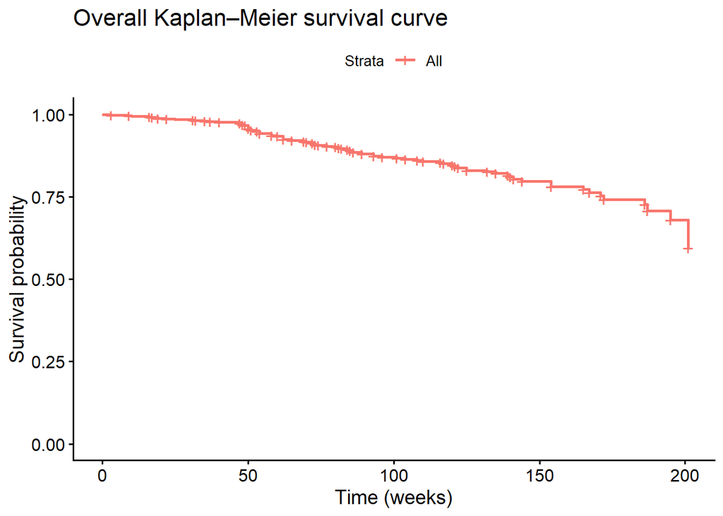

```r
fit_overall <- survfit(Surv(Survival, event) ~ 1, data = mydata)
ggsurvplot(fit_overall, data = mydata,
           conf.int = FALSE,
           xlab = "Time (weeks)",
           title = "Overall Kaplan–Meier survival curve")
```

## 5.2 Survival by RANO response (Rating3)

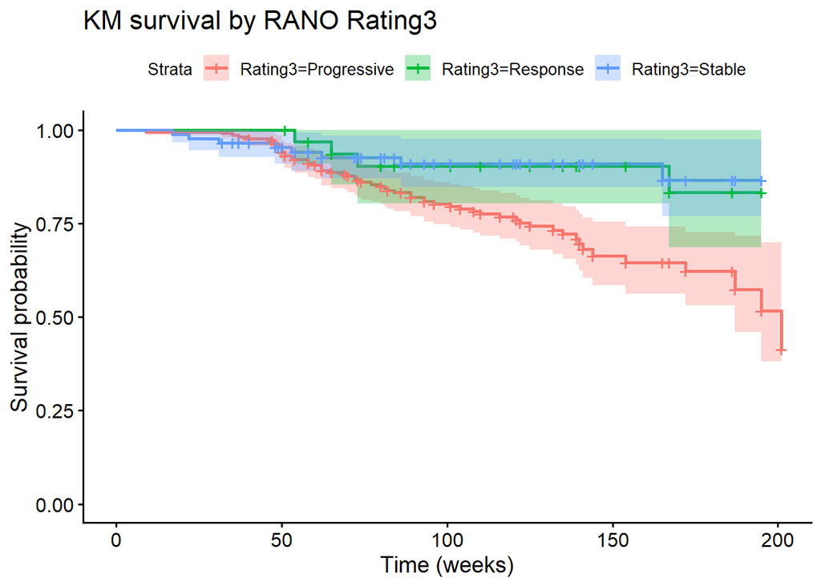

```r
fit_rating3 <- survfit(Surv(Survival, event) ~ Rating3, data = mydata)
ggsurvplot(fit_rating3, data = mydata,
           conf.int = TRUE,
           xlab = "Time (weeks)",
           title = "KM survival by RANO Rating3")
```

# 6 Time-dependent performance: C-index, Brier score, IBS

## 6.1 Complete-case dataset for the final model

```r
eval_vars <- c(
  "Survival", "event",
  "Age.at.surgery..years.",
  "original_shape_Maximum2DDiameterSlice",
  "original_glcm_DifferenceEntropy"
)

eval_data <- mydata %>%
  dplyr::select(all_of(eval_vars)) %>%
  na.omit()

cat("Complete-case eval_data dimensions:\n")
```

```
## Complete-case eval_data dimensions:
```

```r
print(dim(eval_data))
```

```
## [1] 544   5
```

```r
cat("Events in eval_data:\n")
```

```
## Events in eval_data:
```

```r
print(table(eval_data$event))
```

```
##
##   0   1
## 458  86
```

## 6.2 Refit final Cox model on complete cases

```r
form_cc <- Surv(Survival, event) ~
  Age.at.surgery..years. +
  original_shape_Maximum2DDiameterSlice +
  original_glcm_DifferenceEntropy

model_cc <- coxph(form_cc, data = eval_data, x = TRUE, y = TRUE)
summary(model_cc)
```

```
## Call:
## coxph(formula = form_cc, data = eval_data, x = TRUE, y = TRUE)
##
##   n= 544, number of events= 86
##
##                                            coef exp(coef)  se(coef)      z
## Age.at.surgery..years.                 0.090915  1.095176  0.014451  6.291
## original_shape_Maximum2DDiameterSlice  0.026987  1.027355  0.003782  7.136
## original_glcm_DifferenceEntropy       -0.665229  0.514156  0.232534 -2.861
##                                       Pr(>|z|)
## Age.at.surgery..years.                3.15e-10 ***
## original_shape_Maximum2DDiameterSlice 9.60e-13 ***
## original_glcm_DifferenceEntropy        0.00423 **
## ---
## Signif. codes:  0 '***' 0.001 '**' 0.01 '*' 0.05 '.' 0.1 ' ' 1
##
##                                       exp(coef) exp(-coef) lower .95 upper .95
## Age.at.surgery..years.                   1.0952     0.9131     1.065     1.127
## original_shape_Maximum2DDiameterSlice    1.0274     0.9734     1.020     1.035
## original_glcm_DifferenceEntropy          0.5142     1.9449     0.326     0.811
##
## Concordance= 0.771  (se = 0.029 )
## Likelihood ratio test= 89.39  on 3 df,   p=<2e-16
## Wald test            = 89.04  on 3 df,   p=<2e-16
## Score (logrank) test = 93.64  on 3 df,   p=<2e-16
```

## 6.3 Evaluation times (quartiles of follow-up)

```r
eval_times <- as.numeric(quantile(
  eval_data$Survival,
  probs = c(0.25, 0.5, 0.75),
  na.rm = TRUE
))
eval_times
```

```
## [1]  62  96 139
```

## 6.4 Time-dependent C-index at selected times

```r
c_td <- cindex(
  object      = list("Cox_final" = model_cc),
  formula     = Surv(Survival, event) ~ 1,
  data        = eval_data,
  eval.times  = eval_times,
  cens.model  = "cox",
  splitMethod = "noPlan"
)

print(c_td)
```

```
##
## The c-index for right censored event times
##
## Prediction models:
##
## Cox_final
## Cox_final
##
## Right-censored response of a survival model
##
## No.Observations: 544
##
## Pattern:
##                 Freq
##  event          86
##  right.censored 458
##
## Censoring model for IPCW: marginal model (Kaplan-Meier for censoring distribution)
##
## No data splitting: either apparent or independent test sample performance
##
## Estimated C-index in %
##
## $AppCindex
##           time=62 time=96 time=139
## Cox_final    79.1    75.9     76.4
```

```r
cindex_df <- data.frame(
  time_weeks = eval_times,
  Cindex     = as.numeric(c_td$AppCindex$Cox_final),
  Cindex_pct = 100 * as.numeric(c_td$AppCindex$Cox_final)
)
cindex_df
```

| time_weeks | Cindex | Cindex_pct |
| --- | --- | --- |
| 62 | 0.7910315 | 79.10315 |
| 96 | 0.7590740 | 75.90740 |
| 139 | 0.7641326 | 76.41326 |

## 6.5 C-index curve over time

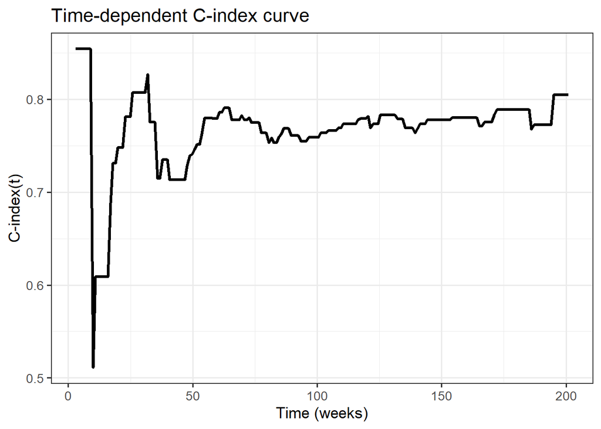

```r
times_grid <- seq(
  min(eval_data$Survival),
  max(eval_data$Survival),
  length.out = 200
)

c_td_curve <- cindex(
  object      = list("Cox_final" = model_cc),
  formula     = Surv(Survival, event) ~ 1,
  data        = eval_data,
  eval.times  = times_grid,
  cens.model  = "cox",
  splitMethod = "noPlan"
)

c_curve <- data.frame(
  time   = times_grid,
  Cindex = as.numeric(c_td_curve$AppCindex$Cox_final)
)

ggplot(c_curve, aes(x = time, y = Cindex)) +
  geom_line(size = 1.1) +
  theme_bw(base_size = 13) +
  labs(
    title = "Time-dependent C-index curve",
    x = "Time (weeks)",
    y = "C-index(t)"
  )
```

## 6.6 Prediction error curve (Brier score) and IBS

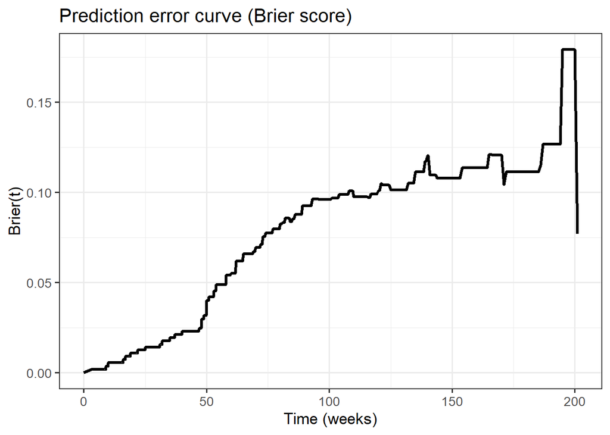

```r
times_grid2 <- seq(
  min(eval_data$Survival),
  max(eval_data$Survival),
  length.out = 200
)

pec_obj <- pec(
  object      = list("Cox_final" = model_cc),
  formula     = Surv(Survival, event) ~ 1,
  data        = eval_data,
  times       = times_grid2,
  cens.model  = "cox",
  splitMethod = "noPlan"
)

brier_df <- data.frame(
  time_weeks = pec_obj$time,
  Brier      = as.numeric(pec_obj$AppErr$Cox_final)
)

ggplot(brier_df, aes(x = time_weeks, y = Brier)) +
  geom_line(size = 1.1) +
  theme_bw(base_size = 13) +
  labs(
    title = "Prediction error curve (Brier score)",
    x = "Time (weeks)",
    y = "Brier(t)"
  )
```

```r
# Approximate Brier at the three eval_times
idx <- sapply(eval_times, function(t) which.min(abs(pec_obj$time - t)))
brier_three <- brier_df[idx, ]
brier_three$target_time <- eval_times
brier_three
```

|  | time_weeks | Brier | target_time |
| --- | --- | --- | --- |
| 84 | 62 | 0.06190246 | 62 |
| 134 | 96 | 0.09614490 | 96 |
| 190 | 139 | 0.11712444 | 139 |

```r
# Integrated Brier Score up to each eval_time
ibs_res <- crps(
  object = pec_obj,
  models = "Cox_final",
  times  = eval_times
)
ibs_res
```

```
##
## Integrated Brier score (crps):
##
##            [,1]
## Cox_final 0.020
## Cox_final 0.041
## Cox_final 0.060
```

## 6.7 Internal validation: bootstrap-based optimism correction

In this section we internally validate the time-dependent performance of the final Cox model using bootstrap resampling. The goal is to obtain optimism-corrected estimates of the time-dependent C-index and prediction error (Brier score and Integrated Brier Score, IBS).

We use two complementary approaches:

1. **Bootstrap .632 for the time-dependent C-index**, via the `cindex()` function.
2. **Bootstrap .632+ for prediction error and IBS**, via the `pec()` function.

For illustration we use a moderate number of bootstrap samples (e.g. `B = 200`), which can be increased in more demanding applications.

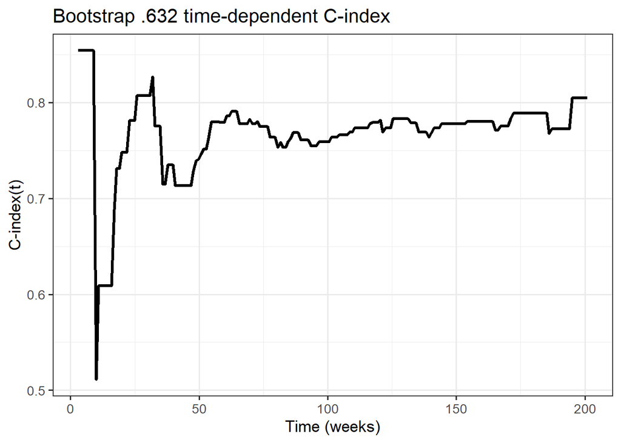

```r
set.seed(20231202)

cindex_boot <- cindex(
  object      = list("Cox_final" = model_cc),
  formula     = Surv(Survival, event) ~ 1,
  data        = eval_data,
  eval.times  = times_grid,
  cens.model  = "cox",
  splitMethod = "boot632",
  B           = 200
)

# Summary of bootstrap .632 C-index over time
cindex_boot_df <- data.frame(
  time_weeks = times_grid,
  Cindex     = as.numeric(cindex_boot$AppCindex$Cox_final)
)

ggplot(cindex_boot_df, aes(x = time_weeks, y = Cindex)) +
  geom_line(size = 1.1) +
  theme_bw(base_size = 13) +
  labs(
    title = "Bootstrap .632 time-dependent C-index",
    x = "Time (weeks)",
    y = "C-index(t)"
  )
```

```r
# Extract C-index at the three pre-specified evaluation times
idx_c <- sapply(eval_times, function(t) which.min(abs(cindex_boot_df$time_weeks - t)))
cindex_boot_three <- cindex_boot_df[idx_c, ]
cindex_boot_three$target_time <- eval_times
cindex_boot_three$Cindex_pct  <- 100 * cindex_boot_three$Cindex
cindex_boot_three
```

|  | time_weeks | Cindex | target_time | Cindex_pct |
| --- | --- | --- | --- | --- |
| 60 | 61.70352 | 0.7859152 | 62 | 78.59152 |
| 94 | 95.53266 | 0.7549825 | 96 | 75.49825 |
| 138 | 139.31156 | 0.7641326 | 139 | 76.41326 |

### 6.7.2 Bootstrap .632+ prediction error and IBS

```r
set.seed(20231202)

pec_boot <- pec(
  object      = list("Cox_final" = model_cc),
  formula     = Surv(Survival, event) ~ 1,
  data        = eval_data,
  times       = times_grid2,
  cens.model  = "cox",
  splitMethod = "Boot632plus",
  B           = 200,
  exact       = FALSE
)
```

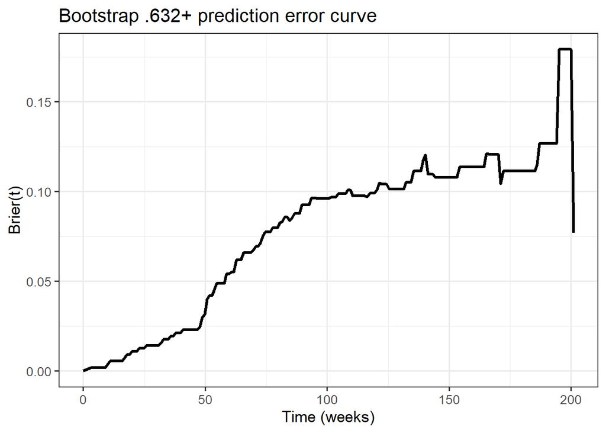

```r
# Bootstrap .632+ prediction error curve
brier_boot_df <- data.frame(
  time_weeks = pec_boot$time,
  Brier      = as.numeric(pec_boot$AppErr$Cox_final)
)

ggplot(brier_boot_df, aes(x = time_weeks, y = Brier)) +
  geom_line(size = 1.1) +
  theme_bw(base_size = 13) +
  labs(
    title = "Bootstrap .632+ prediction error curve",
    x = "Time (weeks)",
    y = "Brier(t)"
  )
```

```r
# Integrated Brier Score up to the three evaluation times (bootstrap .632+)
ibs_boot <- crps(
  object = pec_boot,
  models = "Cox_final",
  times  = eval_times
)
ibs_boot
```

```
##
## Integrated Brier score (crps):
##
## AppErr :
## Cox_final Cox_final Cox_final
##    0.0192    0.0403    0.0590
##
## BootCvErr :
## Cox_final Cox_final Cox_final
##    0.0196    0.0417    0.0611
##
## NoInfErr :
## Cox_final Cox_final Cox_final
##    0.0216    0.0502    0.0834
##
## Boot632plusErr :
## Cox_final Cox_final Cox_final
##    0.0194    0.0412    0.0604
```

# 7 Risk stratification based on Cox linear predictor

```r
eval_data$risk_score <- predict(model_cc, type = "lp")
summary(eval_data$risk_score)
```

```
##    Min. 1st Qu.  Median    Mean 3rd Qu.    Max.
## -2.9619 -0.7978  0.0162  0.0000  0.8247  3.1123
```

```r
eval_data$risk_group <- dplyr::ntile(eval_data$risk_score, 3)
eval_data$risk_group <- factor(eval_data$risk_group,
                               labels = c("Low", "Medium", "High"))

table(eval_data$risk_group)
```

```
##
##    Low Medium   High
##    182    181    181
```

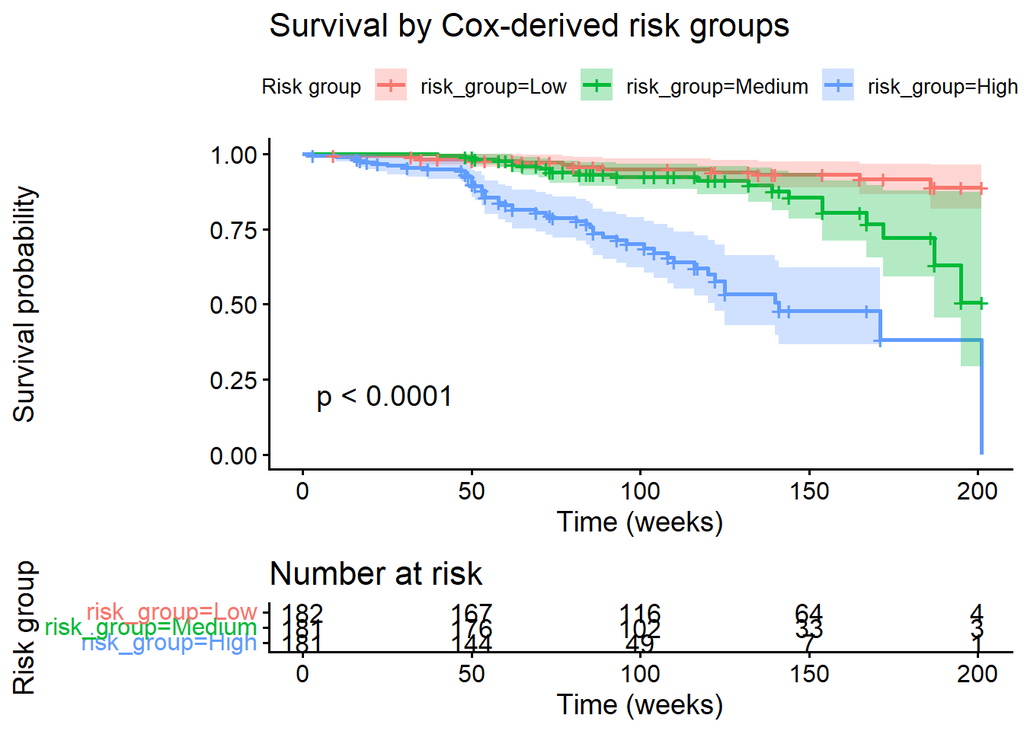

```r
fit_risk <- survfit(Surv(Survival, event) ~ risk_group, data = eval_data)

ggsurvplot(
  fit_risk, data = eval_data,
  conf.int   = TRUE,
  pval       = TRUE,
  risk.table = TRUE,
  xlab       = "Time (weeks)",
  title      = "Survival by Cox-derived risk groups",
  legend.title = "Risk group"
)
```

# 8 Discussion (template)

This section can be edited and expanded into a formal manuscript discussion.

# 9 Reproducibility notes

- Raw LUMIERE data are public but not shipped in this repository.
- Download the CSV files from figshare (DOI above) and place them in `data/`.
- Create a `results/` folder for derived outputs.
- This R Markdown file is suitable both as a GitHub example and as a supplementary methods/results document.
- The main analysis scripts are provided under `scripts/`:
  - `01_preprocess_to_TD_FINAL.R`: preprocessing pipeline to derive `LUMIERE_TD_FINAL.csv`
  - `02_run_survival_models.R`: fits the final Cox model
  - `03_plot_results.R`: creates time-dependent performance and risk-group KM plots
  - `04_export_results.R`: exports summary tables (C-index, IBS, etc.)
  - `05_render_report.R`: renders this R Markdown file to HTML